# CGA 20th Anniversary Annual Conference

Preliminary Program · October 2–3, 2026

[figure not shown]

# **Version**: September 30, 2026

**Some talks have been moved, to maximize presentation time; please check your assignment!**

# Our venue: [The David Rubenstein Treehouse](https://rubensteintreehouse.harvard.edu), Second Floor

**Please make sure you’ve completed the Treehouse security process and have your QR ready for access to our meeting venue!**

# Day 1 · Friday, October 2

## 9:00am–12:00pm · Workshops (CGIS South)

## 12:00–1:00pm · Lunch (on your own)

## 1:00–1:15pm · Conference opening (Riverbend)

- Rachel Franklin · Harvard Center for Geographic Analysis
- Subu Subramanian · Harvard Center for Geographic Analysis and Chan School of Public Health
- Peter Bol · Harvard Center for Geographic Analysis and Department of East Asian Languages and Civilizations

## 1:15–2:00pm · Keynote · Empowering Explorers (Riverbend)

Dawn Wright · Chief Scientist · Environmental Systems Research Institute (Esri)

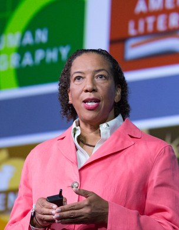

Dawn Wright is Chief Scientist of Esri, working to strengthen the scientific foundation for the company’s products and services. As a research lead both at Esri and Oregon State University, she has produced some of the most definitive literature on geographic information system (GIS) technology for the ocean. An elected member of both the National Academy of Sciences and the National Academy of Engineering, she earned her doctorate in Geography and Geology from UC Santa Barbara. In 2022, Dawn became the first Black person to visit Challenger Deep, the deepest and most unexplored place on planet Earth.

## 2:00–3:00pm · Plenary Panel 1 · Navigating the Shifting Spatial Skills Landscape (Riverbend)

Moderator: Angela Lee · Environmental Systems Research Institute (Esri)

**Panelists:**

- Hamed Alemohammad · Clark University
- Ghermay Araya · New Light Technologies, Inc.
- Lauren Bennett · Environmental Systems Research Institute (Esri)
- Todd Mostak · NVIDIA

## 3:00–3:30pm · Coffee break

## 3:30–4:30pm · Concurrent Sessions 1

### 1A Historical GIS and History (Riverbend)

Chair: Molly Taylor-Poleskey · Harvard University Map Library

- *Historical Geodata Digitization with Vision-Language Models: Reconstructing Neighborhood Property Values and the Geography of Racially Restrictive Covenants in Twentieth-Century Milwaukee*  
  **Elizaveta Lepikhova · UW-Milwaukee**, Daria Dementeva · Luxembourg Institute of Socio-Economic Research (LISER)
- *Automated Georeferencing of Historical Maps Using Vision–Language Models* **Yanan Wu**, Yalin Yang, Chengbin Deng · University of Oklahoma
- *China’s History Through a Geographic Lens*  
  **Peter K. Bol · Harvard University**
- *Before the Map: Early Modern European Itineraries and Network Graphs as an Alternative to HistoricalGIS*  
  **Molly Taylor-Poleskey · Harvard University Map Library**

### 1B Development, Poverty, and Environment (Lane’s Edge)

Chair: Anthony Howell · Arizona State University

- *Multimodal poverty mapping and geographic transfer allocation*  
  **Woojin Jung · Rutgers University**, Andrew H. Kim, Arunesh Sinha, Quentin Stoeffler, Saeed Ghadimi, Vatsal Shah, Krittika Garg, Tawfiq Ammari
- *Household energy choice in rural Ethiopia: An agent-based approach*  
  **Dylan Munson · Duke University**, Rahel Bekele, Yuxin Kang, Scott Duxbury, Sam St. Lawrence, Dana Pasquale
- *Generative AI, Skill Decombination, and the Geography of Work Restructuring*  
  **Anthony Howell · Arizona State University**

### 1C Environmental Exposure and Vulnerability (West Hollow)

Chair: Melie Monnerat · McGill University

- *From Historical GIS to Digital Twins: Modeling Urban Resilience Through Explainable AI in Spain*  
  **Bárbara Polo-Martín · Universidad Autónoma de Madrid**
- *Leveraging Digital Trace Data to Measure Flood-Induced Population Displacement*  
  **Martina Pardy · University of Liverpool**, Elisabetta Pietrostefani, Matt Mason, Andrea Nasuto, Francisco Rowe
- *Spatial Scale Effects in Foundation Model Earth Embeddings: A Case Study on Predicting the Exposure of Structures to Wildfire in Colorado, USA*  
  **Aleksander Berg · University of Colorado Boulder**, Stefan Leyk
- *Looking Below the Canopy: Grounding Geographic Analysis in Vietnam’s Cinnamon Commodity Landscape*  
  **Melie Monnerat · McGill University**

### 1D Panel: Who Writes the Map? AI, Authorship, and Publishing (Branch View)

Moderator: Kexin Song · Yale University

**Panelists**

- Shijuan Chen · University of Massachusetts Boston
- Rachel Franklin · Harvard Center for Geographic Analysis
- Luke Sanford · Yale University
- Zhe (Sarina) Zhang · Texas A&M University

## 4:30–4:45pm · Break

## 4:45–5:45pm · Concurrent Sessions 2

### 2A Health and Access (Riverbend)

Chair: Clio Andris · Georgia Tech

- *Forecast, Prepare, Respond: Geospatial and Machine-Learning Analytics for Public Health and Emergency Medical Services from Global to Local Scale*  
  **Ghermay Araya and Garrett Tate · New Light Technologies, Inc.**
- *LLM-based Generation of Geospatial Synthetic Data for Analyzing Spatial Patterns of Health Outcomes and Disparities*  
  **Haley Mullen · Tufts University**, Kathleen Stewart
- *Uneven Access: Mapping Contraceptive Care Across Texas*  
  **Mahboobe Safaei Mehr · The University of Texas at Austin**
- *Human-Network Regions as Effective Geographic Units for Disease Mitigation*  
  **Clio Andris · Georgia Tech**, Caglar Koylu, Mason A. Porter

### 2B GIS Enterprise, Education, and Governance (Lane’s Edge)

Chair: Jeff Blossom · Harvard Center for Geographic Analysis

- *AI Is Changing Geographic Problem Solving; Instruction Must Change Too*  
  Peter Kedron, **Sarigai Sarigai · UC Santa Barbara**, Heather Baier, Andrew Trgovac
- *GeoAI, meet your library era*  
  **Belle Lipton · Harvard Map Collection** and Julie Goldman
- *Participatory GIS for Campus Sustainability: Geospatial Data Collection, Digital Twin Development, and Sustainability Certification at Historically Black Colleges and Universities*  
  Rebecca Sarpongasiedu, Elliot Nana Karikari, **Amy Yeboah Quarkume · Howard University**
- *Evolution of GIS - Enterprise GIS, Systems Thinking and Governance*  
  **Geri Miller · Esri**

### 2C Lightning Talks (West Hollow)

Chair: Devika Jain · Harvard Center for Geographic Analysis

- *Beyond Proximity: Measuring Quality Childcare Access as Spatial Equity Problem in New York City*  
  **Chaitanya Kukreja · New York University - Center of Urban Science + Progress**
- *The spatial clustering of utility-scale solar in Rhode Island*  
  **Christopher Battle · University of Rhode Island**
- *Visualising Flood Risk: A GIS–Augmented Reality Pipeline for Hyperlocal Urban Flood Education along the River Lea*  
  **Janniah Evans · University College London**
- *Measuring Wildlife Diversity in Chitwan National Park, Nepal Using Thermal UAVs and GIS*  
  **Umme Kulsum · The University of Texas at Dallas**, Fang Qiu
- *Finding the Ground Before the Survey: A Comparative Workflow for Early-Stage Terrain and Site-Context Modeling*  
  **Teresa Xinyan Li · Harvard University**
- *Everywhere she maps, she changes the discourse: A topic modeling of the gender discourse in YouthMappers blogs*  
  **Maliha Binte Mohiuddin · West Virginia University**, Natalia da Silveira Arruda, Patricia Solís, Brajesh Karna, Ebenezer Nana Kwaku Boateng, Courtney Clark
- *From Satellite Detection to Field Intervention: Operational Lessons for GeoAI*  
  **Shoibolina Kaushik · Texas A&M University**, Xiao Huang
- *Labor Mobility in Cannabis Production and Territorial Contradictions in Regulated Markets*  
  **Rogério de Mambro · PPGH - USP (Programa de Pós Graduação em Geografia Humana - Universidade de São Paulo**
- *Past Decisions, Present Barriers, and Future Access: A GIS-Based Analysis of Spatial Disparities in Indigenous Grain Market Access in Manitoba, Canada*  
  **Supul Muhandiram · University of Manitoba**, Narendra Malalgoda
- *Spatial Patterns of Luxury Fashion in Milan: Towards a Typology of Fashion Districts*  
  **Mateusz Rusin · Jagiellonian University**

### 2D Panel: Data-Driven Design for Urban Landscapes: Practicing and Teaching Urban Forest Planning (Branch View)

Moderator: Eric Kramer · Reed Hilderbrand Landscape Architecture and Harvard Graduate School of Design

**Panelists**

- Indrani Gosh · Weston & Sampson
- Slide Kelly · Harvard Graduate School of Design
- Eric Kramer · Reed Hilderbrand Landscape Architecture and Harvard Graduate School of Design
- Max Robert Louis Piana · Harvard Graduate School of Design

# Day 2 · Saturday, October 3

## 9:00–9:15am · Morning Welcome (Riverbend)

## 9:15–10:00am · Keynote 2 · AI: Solution or Obstacle for Climate Adaptation? (Riverbend)

Francesca Dominici · Director · Harvard Data Science Initiative and Clarence James Gamble Professor of Biostatistics · Harvard University

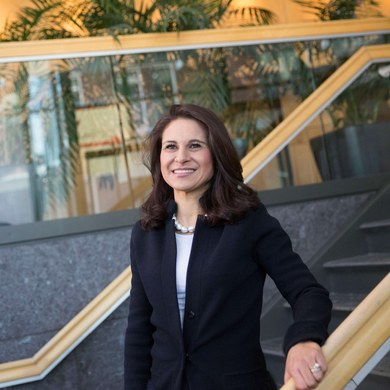

Dr. Francesca Dominici is the Clarence James Gamble Professor of Biostatistics, Population and Data Science at the Harvard T.H. Chan School of Public Health and Director of the Harvard Data Science Initiative. Dr. Dominici is also the founder and lead Principal Investigator for the National Studies on Air Pollution and Health group, and a co-founding PI and leader for the BUSPH-HSPH Climate Change and Health Research Coordinating Center. Dr. Dominici’s research focuses on machine learning, Artificial Intelligence, causal inference, and data science to impact climate and environmental policy. Her studies have directly impacted air quality policy in the U.S.

## 10:00–11:00am · Plenary Panel 2 · Localizing Spatial Intelligence for Crisis Response (Riverbend)

Moderator: Andrew Schroeder · Gates Foundation

**Panelists:**

- Andrew Schroeder · Gates Foundation / CrisisReady
- Liz Chamberlain · Humanitarian Open Street Map Team (HOT)
- Billie Bee · NASA Lifelines
- Nathaniel Raymond · Yale Humanitarian Lab

## 11:00–11:30am · Coffee break

## 11:30am–1:00pm · Concurrent Sessions 3

### 3A Agents, LLMs, and the Discipline (Oh my!) (Riverbend)

Chair: Anthony C. Robinson · Penn State University

- *Spatial Agents: The Next Interface for Geographic Analysis*  
  **Samyuktha Madhusudhan Thumala · Databricks**
- *Evaluating Agentic AI for Geographic Analysis: A Multi-Agent Framework Tested Against Expert Reproductions*  
  **Peter Kedron · UCSB**, Shanyu Luo, Sarigai Sarigai, Andrew Trgovac, Joseph Holler
- *GeoAI Embracing Place?*  
  **Yue Lin · UIUC**, Bo Zhao
- *Responsible GeoAI: Thoughtfully Integrating Geography and AI in the Real World*  
  **Lei Zou · Texas A&M University**
- *Algorithmic Space: Reimagining Geographic Analysis Through AI Governance and Spatial Justice* **Nadine Fares · RBC Royal Bank of Canada**
- *Slop-less Mapmaking in a Reimagined University Cartography Lab*  
  **Anthony C. Robinson · Penn State University**

### 3B Coastal and Landscape Dynamics (Lane’s Edge)

Chair: Garima Jain · Stanford University

- *Sediment sources drive changes in the large-scale distribution, biomass, and species composition of salt marsh vegetation*  
  **Yvanna Serra · Boston University**, Anthony Campbell, Sergio Fagherazzi
- *Detecting and Characterizing Coastal Wetland Surface Water Dynamics Using High-Resolution Remote Sensing and Geospatial Change Analysis*  
  **Aiyin Zhang · Clark University**, Robert Gilmore Pontius Jr, John Rogan, Florencia Sangermano
- *From Satellite Snapshots to Spatial Sediment Budgets: Geographic Analysis of Marsh Vulnerability*  
  **Jordi Palacios · Boston Univerity**, Hangjie Lin, Cedric Fichot, Sergio Fagherazzi
- *Urbanization and wildfire exposure in the wildland urban interface of the Himalayas*  
  **Shijuan Chen · UMass Boston**, Kyle Thomas Manley, Jennifer Kakareka Balch, Volker C Radeloff, Franz Schug, Tzu-Hsin Karen Chen, Karen C. Seto
- *Integration of Three Novel Methods to Characterize Land Cover Change Using a Time Series of Maps in a Coastal Wetland Ecosystem*  
  **Robert Gilmore Pontius Jr · Clark University**, Abigail Phillips, Antonio Victor Galvão da Fonseca, Aiyin Zhang, Sergio Fagherazzi
- *From adaptation to entrapment: Evidence of aquaculture-induced salinity feedback in coastal India*  
  **Garima Jain · Stanford University**, B. L. Turner II, Dylan Connor, Hallie Eakin, Amy E. Frazier

### 3C Political Economy and Statecraft (West Hollow)

Chair: Urska Vrabic-Brodnjak · University of Ljubljana

- *Sanctions in Space: Mapping Regional Economic Exposure with NLP and Spatial Econometrics*  
  **Gianmario Strappati · Instituto Superior de Musica J. Hernandez de Buenos Aires**
- *Politics of Form in the Transpacific: A Geographic Perspective*  
  **Xiao Di Tong · Michigan State University**
- *Local parsimonious approach to measuring gerrymandering effects considering both shape and representation*  
  **Joseph Holler · Middlebury College**
- *Crime, inequality, and urban space: using public safety data to reveal hidden geographies of urban vulnerability in Brazil*  
  **Rafael Mazoni · Fundação João Pinheiro (Brazil)**, Alexandre Diniz
- *Terrain, Signal, and Access: Spatial Analysis of Telecom Networks*  
  **Kyungmin Kim · Harvard University Graduate School of Design**
- *The Geography of Sustainable Packaging Waste in Europe*  
  **Urska Vrabic-Brodnjak · University of Ljubljana**

### 3D Spatial Data and Structures (Branch View)

Chair: Jochen Albrecht · Hunter College / CUNY

- *Tracing Uncertainties and Errors Through the Production Pipeline of Platform POI Data*  
  **Jiahua Chen · University of California, Santa Barbara**, Peter Kedron, Trisalyn Nelson, Kathy Baylis
- *Place, Access, and Attitudes: Validating OpenStreetMap Measures of Infrastructural Deprivation in Political Science*  
  **Daria Dementeva · Luxembourg Institute of Socio-Economic Research (LISER)**, Anne-Kathrin Stroppe · GESIS – Leibniz Institute for the Social Sciences
- *Building the National Zoning Atlas*  
  **Scott Markley · National Zoning Atlas**
- *Spatial Representation and Ambiguity of Study-Site Metadata: Reconstructing Study Sites for a Congo Basin Forest-Change Meta-Analysis*  
  **Emily Zhou · University of California Santa Barbara**, Peter Kedron, Niwaeli Kimambo, Sarah Tolbert, Joseph Holler
- *Distance Decay as a Foundational Geographic Analysis Concept: From Spatial Interaction to Multiscale Spatial Smoothing and Beyond*  
  **Taylor Oshan · University of Maryland**
- *What is Special About Spatial?: Spatiality in the Age of Data Science*  
  **Jochen Albrecht · Hunter College / CUNY**

## 1:00–2:00pm · Networking lunch — (lunch provided!)

## 2:00–3:15pm · Concurrent Sessions 4

### 4A Land Cover, Change, and Conflict (Riverbend)

Chair: Bruce Boucek · Harvard Graduate School of Design

- *A Pixel-Level Framework for Map Comparison Through Time with Application to Water Mapping in Plum Island Ecosystems, MA*  
  **Antonio Victor Galvao da Fonseca · Clark University**, Robert Gilmore Pontius Jr
- *Beyond Forest Loss: Integrating Trajectory Analysis and DynamicPATCH to Understand Land-Use Dynamics in Tropical Protected Areas*  
  **Pacifique Madibi · Clark University**, Jean-Paul Kibambe, Aiyin Zhang, Robert Pontius
- *Exploring Hidden Landscapes - Seeing the Unseen with LiDAR in the Vegetated Terrain of New England and Palestine*  
  **Jeffrey C. Howry · Harvard Museum of the Ancient Near East**
- *GeoAI and Remote Sensing for Conflict, Displacement, and Environmental Change*  
  **Kexin Song · Yale University**, Luke Sanford · Yale University
- *Cross-Regional Attention Networks in Climate Disasters: Mapping Asymmetric Spillovers and Blind Spots*  
  **Yilan Xu · University of Illinois**, Siqi Zheng, Zhentao Shi, Yi Huang, Yichun Fan, Sebastien Box-Couillard

### 4B Mobility and Movement (Lane’s Edge)

Chair: Hande Demirel · Istanbul Technical University

- *From Spatial Accessibility and Time Geography to Measuring Access and Exposure Through Mobile Location Data*  
  **Somayeh Dodge · University of California, Santa Barbara**
- *Movement stops can reflect our behavioral patterns*  
  **Megan Hutchison · The University of Texas at Dallas**, Mariem Gdoura, Heidi Kane, Patricia Sanchez, Christopher Davenport, May Yuan
- *Geographic Analysis of Human Mobility and Animal Movement and Their Interaction Effects: From Spatial Data Science to Generative AI Approaches*  
  **Song Gao · University of Wisconsin-Madison**
- *Developing MEEP: A Platform for Mobility-Aware Environmental Exposure Evaluation within Cities*  
  **Anastasia Soukhov · Western University**, Armita Kar, Devika Jain, Rachel Franklin
- *Floods vs. Urban Mobility: The Role of Geospatial Intelligence in Transport Resilience*  
  **Hande Demirel · Istanbul Technical University**, Gulsah Kılıc

### 4C Systems and Infrastructure (West Hollow)

Chair: Colton Loftus · Lincoln Institute of Land Policy, Center for Geospatial Solutions

- *Discovering Governing Spatial Interaction Mechanisms in Dynamic Urban Systems*  
  Zhongfu Ma, **Di Zhu · University of Minnesota, Twin Cities**
- *Digital Twin and GIS-BIM Integration for Urban Regeneration in Rome*  
  **Emilio Misuriello · Municipalità di Roma Capitale, Esri Italia spa**, Antonio Cianciulli, Antonio Aruta, Domenico Asprone, Laura Lieto, Maurizio Veloccia, Giuseppe Morone
- *A Spatially Explicit Additive GeoAI Architecture for Metropolitan-Scale Spatial Risk Modeling*  
  **Asish Satpathy · Arizona State University**, Sree Nandhan Prabhakar, Sudamshu Rao, Shreyas Ramani
- *The Future of Geospatial Analysis: Accelerated Geospatial Research with GPU Data Processing, Vector Search, and AI*  
  **Todd Mostak · NVIDIA**
- *Reproducible Geospatial Knowledge Graphs with Apache Iceberg and RDF*  
  **Colton Loftus · Lincoln Institute of Land Policy, Center for Geospatial Solutions**

### 4D Panel: From Participatory GIS to Decision-ready Systems: Building Trust in Geospatial AI (Branch View)

Moderator: Shoibolina Kaushik · Texas A&M University

**Panelists**

- Zhe Zhang · Texas A&M University
- Xiao Huang · Emory University
- May Yuan · The University of Texas at Dallas
- Peng Luo · University of Iowa

## 3:15–3:30pm · Break

## 3:30–4:45pm · Concurrent Sessions 5

### 5A GeoAI and Spatial Analysis (Riverbend)

Chair: Zifu Wang · Harvard Center for Geographic Analysis

- *Quantum Spatial Regression (QSR): Learning Spatial Structure with Quantum Kernels*  
  **Xiao Huang · Emory**
- *Where to Enter: Bayesian Spatial Modeling of Market Entry Success*  
  **Jaiany Rocha Trindade · Harvard University / UFRGS**, Vinicius Andrade Brei, Devika Jain
- *Spatially Aware Adaptive Experimentation*  
  **Lixi Xu · UC Santa Barbara**, Peter Kedron
- *SECT: A Spatiotemporal Explicit Causal Transformer for Path-Faithful Spatiotemporal Attribution*  
  Jikun Liu, **Zhe Zhang · Texas A&M University**, Nanzhou Hu, Yuan Niu
- *An LLM-Guided Framework for Analyzing Public Sentiment Toward Transportation Facilities Using Google Maps Reviews*  
  **Yingrui Zhao · University of Maryland, College Park**
- *Safety-Aware Contraction Hierarchies for School Bus Routing with Maneuver-Level Turn Penalties*  
  **Zifu Wang · Harvard Center for Geographic Analysis**, Yu Zhou, Xueqiao Huang, Jason Wang, Nan Ding

### 5B Segregation and Structural Inequalities (Lane’s Edge)

Chair: Matt Wilson · University of Kentucky

- *Persistent and Emerging Geographies of Structural Racism and Discrimination in the United States*  
  **Debs Ghosh · University of Connecticut**, Youshuang Hu
- *Segregation you cannot see on a map: the social reach of the color line*  
  **Mehak Sachdeva · Florida State University**
- *Mapping Aspiration: Lifestyle Change and Amenity Geographies in Seoul, 1995–2022*  
  **Yona Chung · Harvard University Graduate School of Design**
- *Writing the Speculative City: Reading Amaravati’s Land Pooling Schedules as Relational Statecraft*  
  **Anand Datla · Texas A&M University**
- *A behavioral census of US cities from interpretable mobility embeddings*  
  **Hamish Gibbs · Northeastern University**

### 5C Foundation Models and Earth Embeddings (West Hollow)

Chair: Siqin Wang · University of Southern California

- *Spatial AI for Spatiotemporal Satellite Image Fusion*  
  **Fangzheng Lyu · Virginia Tech**, Zijun Yang, Chunyuan Diao, Shaowen Wang
- *General Geospatial Inference with a Population Dynamics Foundation Model*  
  Mohit Agarwal, Mimi Sun, Chaitanya Kamath, **Arbaaz Muslim · Google**, Prithul Sarker, Joydeep Paul, Gautam Prasad
- *GeoFM2Flow: Generating Human Mobility Flows from Geospatial Foundation Model Embeddings*  
  **Zhongfu Ma · University of Minnesota Twin Cities**, Meicheng Xiong, Di Zhu
- *Advancing Geographic Analysis with Multimodal Large Language Models: Uncovering Perceptual Mechanisms of Urban Coastal Vitality*  
  **Peijin Sun · University of North Carolina at Chapel Hill**
- *Benchmark evaluation of large language models for human versus AI perception on urban environment through street view images*  
  **Siqin Wang · University of Southern California**, Zifu Wang, Xiao Huang, Lingbo Liu, Zhecheng Shi, Zongrong Li

### 5D Panel: The Future of University GIS Centers in the AI Era (Branch View)

Moderator: Chengbin Deng · University of Oklahoma

**Panelists**

- Alex de Sherbinin · Columbia University
- Alan Murray · UC Santa Barbara
- Deepak Mishra · University of Georgia
- Jennifer Swenson · William & Mary
- Wenwen Li · Arizona State University

## 4:45–5:00pm · Break

## 5:00–5:45pm · Keynote 3 · Seeing Through the Silicon Gaze: Mapping Bias in Large Language Models (Riverbend)

Matthew Zook · Roger DiSilvestro Professor · Department of Geography · University of Kentucky

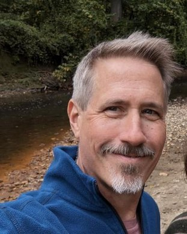

Matthew Zook is a University Research Professor and Roger DiSilvestro Professor in the Department of Geography at the University of Kentucky focused on Urban and Digital Geographies. His work combines critical approaches from urban planning, data/software studies, and heterodox economics with technical and qualitative methods to analyze how urban technologies and data-driven systems reshape cities and governance. He is currently Editor-in-Chief of the open-access SAGE journal Big Data & Society and a co-editor of Elsevier’s Progress in Economic Geography.

## 5:45–6:00pm · Conference Closing and Prizes

- Jeff Blossom · Harvard Center for Geographic Analysis
- Rachel Franklin · Harvard Center for Geographic Analysis

# Index

## A

- Mohit Agarwal (5C)
- Jochen Albrecht (3D)
- Hamed Alemohammed (Plenary Panel 1)
- Tawfiq Ammari (1B)
- Clio Andris (2A)
- Ghermay Araya (Plenary Panel 1, 2A)
- Natalia da Silveira Arruda (2C)
- Antonio Aruta (4C)
- Domenico Asprone (4C)

## B

- Heather Baier (2B)
- Jennifer Kakareka Balch (3B)
- Christopher Battle (2C)
- Kathy Baylis (3D)
- Billie Bee (Plenary Panel 2)
- Rahel Bekele (1B)
- Lauren Bennett (Plenary Panel 1)
- Aleksander Berg (1C)
- Jeff Blossom (2B)
- Ebenezer Nana Kwaku Boateng (2C)
- Peter K. Bol (1A)
- Bruce Boucek (4A)
- Sebastien Box-Couillard (4A)
- Vinicius Andrade Brei (5A)

## C

- Anthony Campbell (3B)
- Liz Chamberlain (Plenary Panel 2)
- Jiahua Chen (3D)
- Shijuan Chen (1D, 3B)
- Tzu-Hsin Karen Chen (3B)
- Yona Chung (5B)
- Antonio Cianciulli (4C)
- Courtney Clark (2C)
- Dylan Connor (3B)

## D

- Anand Datla (5B)
- Christopher Davenport (4B)
- Daria Dementeva (1A, 3D)
- Hande Demirel (4B)
- Chengbin Deng (1A, 5D)
- Chunyuan Diao (5C)
- Nan Ding (5A)
- Alexandre Diniz (3C)
- Somayeh Dodge (4B)
- Francesca Dominici (Keynote 2)
- Scott Duxbury (1B)

## E

- Hallie Eakin (3B)
- Janniah Evans (2C)

## F

- Sergio Fagherazzi (3B)
- Yichun Fan (4A)
- Nadine Fares (3A)
- Cedric Fichot (3B)
- Antonio Victor Galvão da Fonseca (3B, 4A)
- Rachel Franklin (1D, 4B)
- Amy E. Frazier (3B)

## G

- Song Gao (4B)
- Krittika Garg (1B)
- Mariem Gdoura (4B)
- Saeed Ghadimi (1B)
- Debs Ghosh (5B)
- Hamish Gibbs (5B)
- Julie Goldman (2B)
- Indrani Gosh (2D)

## H

- Joseph Holler (3A, 3C, 3D)
- Anthony Howell (1B)
- Jeffrey C. Howry (4A)
- Nanzhou Hu (5A)
- Youshuang Hu (5B)
- Xiao Huang (2C, 4D, 5A, 5C)
- Xueqiao Huang (5A)
- Yi Huang (4A)
- Megan Hutchison (4B)

## J

- Devika Jain (2C, 4B, 5A)
- Garima Jain (3B)
- Robert Gilmore Pontius Jr (3B, 4A)
- Woojin Jung (1B)

## K

- Chaitanya Kamath (5C)
- Heidi Kane (4B)
- Yuxin Kang (1B)
- Armita Kar (4B)
- Elliot Nana Karikari (2B)
- Brajesh Karna (2C)
- Shoibolina Kaushik (2C, 4D)
- Peter Kedron (2B, 3A, 3D, 5A)
- Slide Kelly (2D)
- Jean-Paul Kibambe (4A)
- Andrew H. Kim (1B)
- Kyungmin Kim (3C)
- Niwaeli Kimambo (3D)
- Caglar Koylu (2A)
- Eric Kramer (2D)
- Chaitanya Kukreja (2C)
- Umme Kulsum (2C)
- Gulsah Kılıc (4B)

## L

- Sam St. Lawrence (1B)
- Angela Lee
- Elizaveta Lepikhova (1A)
- Stefan Leyk (1C)
- Teresa Xinyan Li (2C)
- Wenwen Li (5D)
- Zongrong Li (5C)
- Laura Lieto (4C)
- Hangjie Lin (3B)
- Yue Lin (3A)
- Belle Lipton (2B)
- Jikun Liu (5A)
- Lingbo Liu (5C)
- Colton Loftus (4C)
- Peng Luo (4D)
- Shanyu Luo (3A)
- Fangzheng Lyu (5C)

## M

- Zhongfu Ma (4C, 5C)
- Pacifique Madibi (4A)
- Narendra Malalgoda (2C)
- Rogério de Mambro (2C)
- Kyle Thomas Manley (3B)
- Scott Markley (3D)
- Matt Mason (1C)
- Rafael Mazoni (3C)
- Mahboobe Safaei Mehr (2A)
- Geri Miller (2B)
- Deepak Mishra (5D)
- Emilio Misuriello (4C)
- Maliha Binte Mohiuddin (2C)
- Melie Monnerat (1C)
- Giuseppe Morone (4C)
- Todd Mostak (Plenary Panel 1, 4C)
- Supul Muhandiram (2C)
- Haley Mullen (2A)
- Dylan Munson (1B)
- Alan Murray (5D)
- Arbaaz Muslim (5C)

## N

- Andrea Nasuto (1C)
- Trisalyn Nelson (3D)
- Yuan Niu (5A)

## O

- Taylor Oshan (3D)

## P

- Jordi Palacios (3B)
- Martina Pardy (1C)
- Dana Pasquale (1B)
- Joydeep Paul (5C)
- Abigail Phillips (3B)
- Max Robert Louis Piana (2D)
- Elisabetta Pietrostefani (1C)
- Bárbara Polo-Martín (1C)
- Robert Pontius (4A)
- Mason A. Porter (2A)
- Sree Nandhan Prabhakar (4C)
- Gautam Prasad (5C)

## Q

- Fang Qiu (2C)
- Amy Yeboah Quarkume (2B)

## R

- Volker C Radeloff (3B)
- Shreyas Ramani (4C)
- Sudamshu Rao (4C)
- Nathaniel Raymond (Plenary Panel 2)
- Anthony C. Robinson (3A)
- John Rogan (3B)
- Francisco Rowe (1C)
- Mateusz Rusin (2C)

## S

- Mehak Sachdeva (5B)
- Patricia Sanchez (4B)
- Luke Sanford (1D, 4A)
- Florencia Sangermano (3B)
- Sarigai Sarigai (2B, 3A)
- Prithul Sarker (5C)
- Rebecca Sarpongasiedu (2B)
- Asish Satpathy (4C)
- Andrew Schroeder (Plenary Panel 2)
- Franz Schug (3B)
- Yvanna Serra (3B)
- Karen C. Seto (3B)
- Vatsal Shah (1B)
- Alex de Sherbinin (5D)
- Zhecheng Shi (5C)
- Zhentao Shi (4A)
- Arunesh Sinha (1B)
- Patricia Solís (2C)
- Kexin Song (1D, 4A)
- Anastasia Soukhov (4B)
- Kathleen Stewart (2A)
- Quentin Stoeffler (1B)
- Gianmario Strappati (3C)
- Anne-Kathrin Stroppe (3D)
- Mimi Sun (5C)
- Peijin Sun (5C)
- Jennifer Swenson (5D)

## T

- Garrett Tate (2A)
- Molly Taylor-Poleskey (1A)
- Samyuktha Madhusudhan Thumala (3A)
- Sarah Tolbert (3D)
- Xiao Di Tong (3C)
- Andrew Trgovac (2B, 3A)
- Jaiany Rocha Trindade (5A)
- B. L. Turner II (3B)

## V

- Maurizio Veloccia (4C)
- Urska Vrabic-Brodnjak (3C)

## W

- Jason Wang (5A)
- Shaowen Wang (5C)
- Siqin Wang (5C)
- Zifu Wang (5A, 5C)
- Matt Wilson (5B)
- Dawn Wright (Keynote 1)
- Yanan Wu (1A)

## X

- Meicheng Xiong (5C)
- Lixi Xu (5A)
- Yilan Xu (4A)

## Y

- Yalin Yang (1A)
- Zijun Yang (5C)
- May Yuan (4B, 4D)

## Z

- Aiyin Zhang (3B, 4A)
- Zhe (Sarina) Zhang (1D, 4D, 5A)
- Bo Zhao (3A)
- Yingrui Zhao (5A)
- Siqi Zheng (4A)
- Emily Zhou (3D)
- Yu Zhou (5A)
- Di Zhu (4C, 5C)
- Matthew Zook (Keynote 3)
- Lei Zou (3A)